# 1 Que tamanho de luvas vou fabricar?

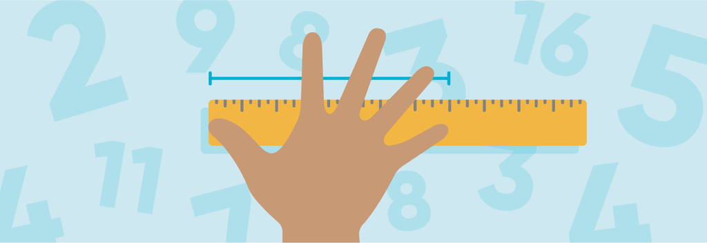

Figure 1.1: Tomando a medida do palmo da mão

## 1.1 Objetivo

Mostrar aos espectadores como o cotidiano reproduz padrões estatísticos. Nesse caso, como um caso aparentemente trivial de medir o tamanho do palmo da mão aponta para a presença da distribuição normal no dia a dia.

## 1.2 Descrição

Os participantes são convidados a medirem com uma régua o palmo de suas mãos. As medidas são então registradas na folha específica, separadas por sexo. Os registros são apresentados e a teoria é discutida.

## 1.3 Itens necessários

São necessárias apenas uma régua e uma folha grande, plastificada, para anotar os resultados. Após um número considerável de execuções, a folha se tornará um registro das probabilidades empíricas associadas ao experimento.

## 1.4 Execução

1. O monitor convida as pessoas a medirem suas mãos, ainda sem dar detalhes sobre o experimento.
2. Após os espectadores medirem suas mãos e os resultados serem anotados, o monitor os apresenta os resultados, instigando-os a levantarem hipóteses sobre o comportamento visual dos dados, com questionamentos sobre o formato, as diferentes frequências entre os valores extremos e centrais, e as diferenças e semelhanças entre as observações para os diferentes sexos.
3. Após levantadas algumas hipóteses, a teoria é discutida.

## 1.5 Teoria

### 1.5.1 Distribuição normal

Ao anotar o tamanho da palma da mão de um tamanho arbitrariamente grande de participantes, espera-se obter a silhueta de uma curva da distribuição normal, que ocorre porque a distribuição do tamanho médio das mãos, tal como várias outras medidas fisiológicas dos seres humanos, segue tal distribuição.

A distribuição normal é uma distribuição de probabilidade contínua, com parâmetros $\mu$ e $\sigma^2$, com função densidade de probabilidade dada por:

$$f(x) = \frac{1}{\sigma\sqrt{2\pi}}e^{-\frac{1}{2}\big(\frac{x-\mu}{\sigma}\big)^2}, \ -\infty < x < \infty$$

Para uma váriável aleatória X que segue distribuição normal, dizemos que $X \sim N (\mu, \sigma^2)$.

A distribuição normal é uma forma de representar dados numéricos que são tipicamente distribuídos em torno de um valor médio central. Quando esses dados são plotados em um gráfico, eles formam uma curva simétrica em formato de “sino”. A área abaixo da curva representa a probabilidade de ocorrerem diferentes valores dentro do conjunto de dados.

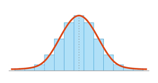

Os dois parâmetros da distribuição normal são a média e a variância. Enquanto a média representa o valor central ao redor do qual os dados tendem a se agrupar, a variância mede a dispersão desses dados em relação à média. Quanto menor for a variância, mais concentrados e próximos da média serão os dados, e quanto maior for esta, mais dispersos eles serão.

Algumas características da distribuição normal são:

- Simetria em torno da média: A quantidade de observações abaixo e acima da média são proporcionais.
- Formato de “sino”: A distribuição normal tem uma forma de sino característica, onde a maioria dos valores está concentrada em torno do valor médio.
- Aplicabilidade em fenômenos naturais: A distribuição normal é amplamente utilizada para modelar fenômenos naturais e sociais, pois muitos eventos na vida real tendem a seguir padrões próximos à distribuição normal.

A distribuição do tamanho do palmo da mão de ambos os sexos segue uma distribuição normal; no entanto, foi observado que o tamanho médio do palmo da mão dos indivíduos do sexo masculino é maior que o tamanho médio do palmo da mão das indivíduas do sexo feminino.

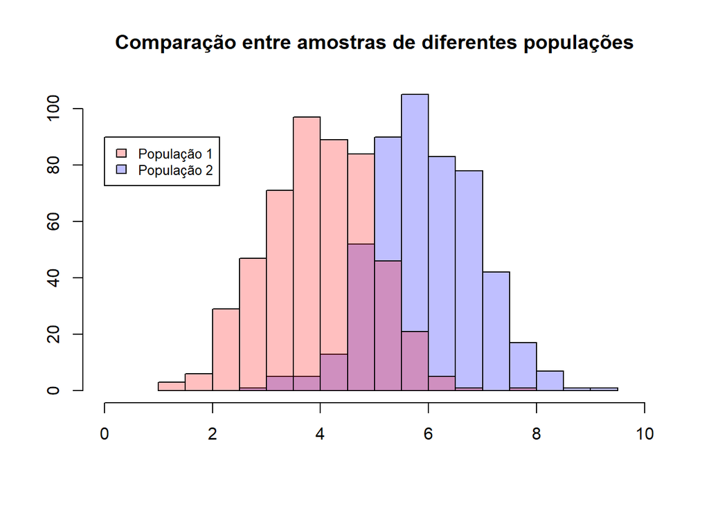

Na Figura 1.3, temos como exemplo dois histogramas representativos de duas amostras de tamanho 500 retiradas de duas populações distintas. Ambas as populações seguem uma distribuição normal, apresentam mesma variância, porém apresentam médias diferentes. Em particular, a população 1 tem média 4, enquanto a população 2 tem média 6.

> É importante ressaltar que qualquer adição ou mudança na explicação da teoria para torná-la mais clara e acessível aos participantes é bem-vinda. Diversos são os visitantes da mostra e a explicação que é óbvia para alguns pode ser confusa para outros.

## 1.6 Aplicação prática

Você já tentou comprar uma roupa, ou tênis, e percebeu que os tamanhos que mais vendem, e também existem em maior quantidade, são os médios? Tem alguma medida corporal em que você se considera acima da média, e por isso tem dificuldades em encontrar vestuário? Percebe que geralmente há poucas unidades dos tamanhos muito grandes?

Essa é uma característica da distribuição normal: suas aplicações em diversas áreas da sociedade. Quando percebemos que algum atributo segue uma distribuição normal, podemos fazer previsões a respeito dele. Por exemplo, um lojista que compreende que as medidas humanas geralmente seguem uma distribuição normal optará por manter em maior quantidade em seu estoque os tamanhos que correspondem a uma parcela maior da população. Isso ocorre porque manter muitas unidades excessivamente grandes pode resultar em prejuízo devido à baixa procura.

## 1.7 Referências e leituras complementares

**Paul Meyer**. Probabilidade - Aplicações à Estatística, capítulo 9.3. “Propriedades Da Distribuição Normal”.

Figure 1.1 - Disponível em https://www.hmhco.com/blog/hand-span-measurement